# 1 - Working with multiple texts

2026-02-11

# Working with multiple texts

We are going to learn how to deal with multiple texts in dataframes, organizing them in a tidy way.

## Jane Austen novels

For this task, we will be working with the 6 published novels from [Jane Austen](https://en.wikipedia.org/wiki/Jane_Austen), the English novelist from the 18th century:

- Sense and Sensibility (1811)
- Pride and Prejudice (1813)
- Mansfield Park (1814)
- Emma (1815)
- Northanger Abbey (1818)
- Persuasion (1818)

We will have a library ([janeaustenr](https://cran.r-project.org/web/packages/janeaustenr/index.html)) containing these 6 novels ready for text analysis: in plain text and splitted by lines. Let’s call and see it.

```r
library(janeaustenr)
#this is a function from this library to show a sample of the first lines
austen_books()
```

|  | text | book |
| --- | --- | --- |
| 1 | SENSE AND SENSIBILITY | Sense & Sensibility |
| 2 |  | Sense & Sensibility |
| 3 | by Jane Austen | Sense & Sensibility |
| 4 |  | Sense & Sensibility |
| 5 | (1811) | Sense & Sensibility |
| 6 |  | Sense & Sensibility |
| 7 |  | Sense & Sensibility |
| 8 |  | Sense & Sensibility |
| 9 |  | Sense & Sensibility |
| 10 | CHAPTER 1 | Sense & Sensibility |

[output cut: 9990 more lines]

We’ve got just two columns: text, and book.

## Adding the chapter

It would be useful to have another variable to know which **chapter** each line comes from. Let’s add it.

```r
library(dplyr)
library(stringr)

original_austen_books <- austen_books() %>%
  #we group by book just for a while
  group_by(book) %>%
  #we create a new variable with consecutive numbers, just to keep track of lines
  mutate(linenumber = row_number(),
         #we use a regex to identify chapters beginning
         chapter = cumsum(str_detect(text,
                                     regex("^chapter [\\divxlc]",
                                           # [\\divxlc] is any character or roman numeral
                                          ignore_case = TRUE)))) %>%
  #and we ungroup
  ungroup()

original_austen_books
```

| text | book | linenumber | chapter |
| --- | --- | --- | --- |
| SENSE AND SENSIBILITY | Sense & Sensibility | 1 | 0 |
|  | Sense & Sensibility | 2 | 0 |
| by Jane Austen | Sense & Sensibility | 3 | 0 |
|  | Sense & Sensibility | 4 | 0 |
| (1811) | Sense & Sensibility | 5 | 0 |
|  | Sense & Sensibility | 6 | 0 |
|  | Sense & Sensibility | 7 | 0 |
|  | Sense & Sensibility | 8 | 0 |
|  | Sense & Sensibility | 9 | 0 |
| CHAPTER 1 | Sense & Sensibility | 10 | 1 |

[output cut: 9990 more lines]

## Tokenizing

Now, we need to tokenize the texts. We already have them splitted by lines, let’s just split them into tokens and put them into the variable `tidy_austen_books`. We already know which function gets that: **please write it under the comment**.

```r
library(tidytext)
#we save it to a new variable
tidy_austen_books <- original_austen_books %>%
  #we tokenize it
  unnest_tokens(word, text)

tidy_austen_books
```

| book | linenumber | chapter | word |
| --- | --- | --- | --- |
| Sense & Sensibility | 1 | 0 | sense |
| Sense & Sensibility | 1 | 0 | and |
| Sense & Sensibility | 1 | 0 | sensibility |
| Sense & Sensibility | 3 | 0 | by |
| Sense & Sensibility | 3 | 0 | jane |
| Sense & Sensibility | 3 | 0 | austen |
| Sense & Sensibility | 5 | 0 | 1811 |
| Sense & Sensibility | 10 | 1 | chapter |
| Sense & Sensibility | 10 | 1 | 1 |
| Sense & Sensibility | 13 | 1 | the |

[output cut: 9990 more lines]

Do you see anything weird in the words? Something not useful, that should not be there? Look at the words again.

## Filtering stopwords

Stopwords are words that are not useful for analysis, typically extremely common words in language such as “the”, “of”, “to”, and so forth in English. To filter them, we need to start from a list. Hopefully, we’ve got one in `tidytext` built upon 3 different lexicons (SMART, snowball and onix). Let’s have a look.

```r
stop_words
```

| word | lexicon |
| --- | --- |
| a | SMART |
| a's | SMART |
| able | SMART |
| about | SMART |
| above | SMART |
| according | SMART |
| accordingly | SMART |
| across | SMART |
| actually | SMART |
| after | SMART |

[output cut: 1139 more lines]

So now, let’s remove stopwords from the whole novels with [`anti_join()`](https://dplyr.tidyverse.org/reference/filter-joins.html).

The `anti_join` function proves useful when we find ourselves wanting to **identify the records from one table that do NOT match another table.**

In this case, for our dataframe of novels, we only want words that are NOT in the stopwords list.

```r
tidy_austen_books <- tidy_austen_books %>%
  anti_join(stop_words)
tidy_austen_books
```

| book | linenumber | chapter | word |
| --- | --- | --- | --- |
| Sense & Sensibility | 1 | 0 | sense |
| Sense & Sensibility | 1 | 0 | sensibility |
| Sense & Sensibility | 3 | 0 | jane |
| Sense & Sensibility | 3 | 0 | austen |
| Sense & Sensibility | 5 | 0 | 1811 |
| Sense & Sensibility | 10 | 1 | chapter |
| Sense & Sensibility | 10 | 1 | 1 |
| Sense & Sensibility | 13 | 1 | family |
| Sense & Sensibility | 13 | 1 | dashwood |
| Sense & Sensibility | 13 | 1 | settled |

[output cut: 9990 more lines]

## Counting word frequencies

We want to know how many times a word is mentioned in Austen’s novels, so we use the function `count`.

```r
tidy_austen_books %>%
  count(word, sort = TRUE)
```

| word | n |
| --- | --- |
| miss | 1855 |
| time | 1337 |
| fanny | 862 |
| dear | 822 |
| lady | 817 |
| sir | 806 |
| day | 797 |
| emma | 787 |
| sister | 727 |
| house | 699 |

[output cut: 9990 more lines]

And why not visualizing it? Let’s make a simple plot with words and frequencies.

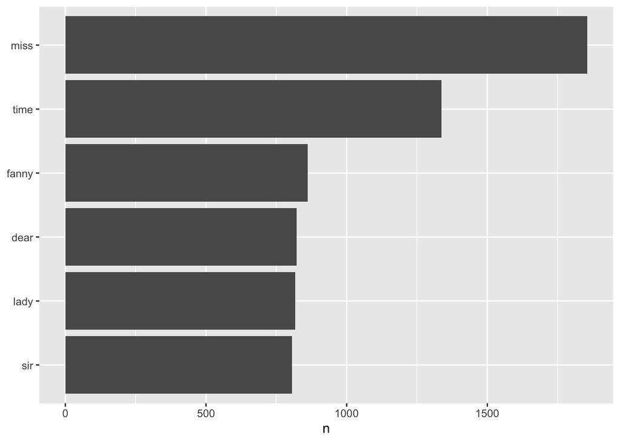

```r
library(ggplot2)

tidy_austen_books |>
  count(word, sort = TRUE) |>
  #only words mentioned over 800 times in the novels
  filter(n > 800) |>
  #we reorder words by number of mentions
  mutate(word = reorder(word, n)) |>
  #we create the plot with the word (x) and the number of mentions (y)
  ggplot(aes(n, word)) +
  geom_col() +
  labs(y = NULL)
```

**Exercise**: Try the same plot with words that are mentioned fewer times, and find some patterns that explain Jane Austen’s writing style or main topics.

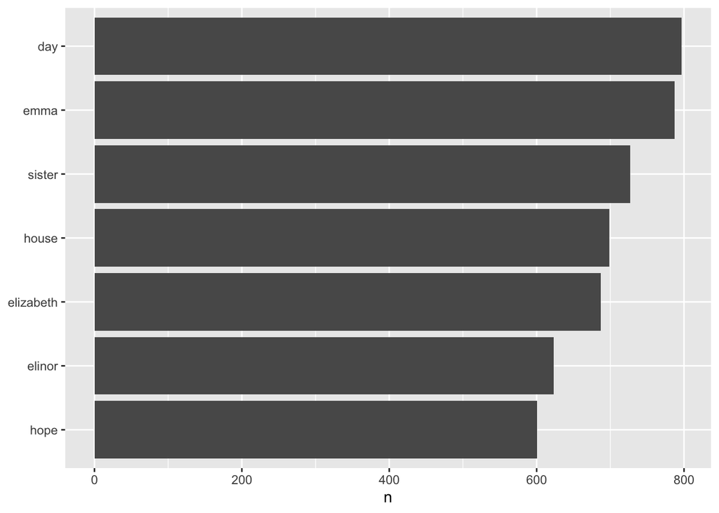

```r
tidy_austen_books |>
  count(word, sort = TRUE) |>
  #only words mentioned over 800 times in the novels
  filter(n > 600) |>
  filter(n < 800) |>
  #we reorder words by number of mentions
  mutate(word = reorder(word, n)) |>
  #we create the plot with the word (x) and the number of mentions (y)
  ggplot(aes(n, word)) +
  geom_col() +
  labs(y = NULL)
```

Insights: her words are related to emotions and most of her characters are women.

## Comparing word frequencies across texts

We can guess now the main characteristics of Jane Austen’s text looking at her word selection, but it would be much more informative if we could compare her to other authors’ word frequencies.

### Project Gutenberg

In order to achieve this, we will be using the [Project Gutenberg](https://www.gutenberg.org/), a digital repository of thousands of books that you surely know.

The `gutenbergr` package provides access to the public domain books from the Project. It includes:

- tools for downloading books (stripping out the unhelpful header/footer information),
- and a complete dataset of metadata that can be used to find works of interest.

We will mostly use the function [`gutenberg_download()`](https://docs.ropensci.org/gutenbergr/reference/gutenberg_download.html) that downloads one or more works from Project Gutenberg by ID. Each book is associated to a number.

```r
#We install the package
# install.packages("gutenbergr")
```

### Preparing H.G. Wells

First, we will download some novels from [Herbert George Wells](https://en.wikipedia.org/wiki/H._G._Wells), an English novelist who lived between the end of the 19th century and the beginning of the 20th. He is mostly famous for his novel “The War of the Worlds”. Here we will be working with:

- The War of the Worlds (1897)
- The Time Machine (1895)
- The Island of Dr. Moreau (1896)
- The invisible man (1897)

```r
library(gutenbergr)
#Download the books by ID (it takes a while, don't panic)
hgwells <- gutenberg_download(c(35, 36, 5230, 159))
```

```
## Using mirror https://aleph.pglaf.org.
```

We get a tibble with just two columns: gutenberg ID and line.

With the function `distinct` we can check that all IDs have been downloaded.

```r
library(dplyr)
distinct(hgwells, gutenberg_id)
```

| gutenberg_id |
| --- |
| 35 |
| 36 |
| 5230 |
| 159 |

**Exercise**: prepare HG Wells novels for analysis:

1. tokenize them by word with default options,
2. filter stopwords and
3. count word frequencies in a separate cell.

Save the result from the beginning in a variable called `tidy_hgwells`.

```r
tidy_hgwells <- hgwells |>
  unnest_tokens(word, text) |>
  anti_join(stop_words)
tidy_hgwells |>
  count(word, sort = TRUE)
```

| word | n |
| --- | --- |
| time | 461 |
| people | 302 |
| door | 260 |
| heard | 249 |
| black | 232 |
| stood | 229 |
| white | 224 |
| hand | 218 |
| kemp | 213 |
| eyes | 210 |

[output cut: 9990 more lines]

Note that we lose now the variable “gutenberg_id”, because word count are aggregated data: now we are using all books to count.

H.G. Wells is prepared for work now.

### Preparing the Brontës

Let’s switch now to a rather different style. We will be working with some novels from the three Brontë sisters, Charlotte, Emily and Anne, English writers who lived in the 19th century, and who are **supposedly closest in writing to Jane Austen** than H.G. Wells. We will be using:

- Wuthering Heights (Emily, 1847) - Gutenberg code: `768`
- The Tenant of Wildfell Hall (Anne, 1848) - Gutenberg code: `969`
- Villette (Charlotte, 1853) - Gutenberg code: `9182`
- Agnus Grey (Anne, 1847) - Gutenberg code: `767`

**Exercise**: Download the Brontës’ novels from Gutenberg, tokenize them with default options, filter stopwords and count word frequencies.

Note: remember it takes a little longer to download the books, so do it in a separate cell.

```r
bronte <- gutenberg_download(c(768, 969, 9182, 767))
```

The Brontës’ are prepared for work now.

```r
library(dplyr)
distinct(bronte, gutenberg_id)
```

| gutenberg_id |
| --- |
| 768 |
| 969 |
| 9182 |
| 767 |

```r
tidy_bronte <- bronte |>
  unnest_tokens(word, text) |>
  anti_join(stop_words)
tidy_bronte
```

| gutenberg_id | word |
| --- | --- |
| 768 | wuthering |
| 768 | heights |
| 768 | emily |
| 768 | brontë |
| 768 | chapter |
| 768 | 1801 |
| 768 | returned |
| 768 | visit |
| 768 | landlord |
| 768 | solitary |

[output cut: 9990 more lines]

```r
tidy_bronte |>
  count(word, sort = TRUE)
```

| word | n |
| --- | --- |
| time | 821 |
| don’t | 625 |
| day | 593 |
| hand | 585 |
| miss | 544 |
| eyes | 527 |
| till | 472 |
| heart | 469 |
| half | 449 |
| night | 430 |

[output cut: 9990 more lines]

### Crossing the authors

Now, let’s compare Jane Austen, H.G. Wells and the Bronte novels by crossing their word frequencies, and put them in a single dataframe called `frequency`.

```r
library(tidyr)
#we start by creating a column called author, distributed by each author dataframe. Bind_rows combines df vertically.
frequency <- bind_rows(mutate(tidy_bronte, author = "Brontë Sisters"),
                       mutate(tidy_hgwells, author = "H.G. Wells"),
                       mutate(tidy_austen_books, author = "Jane Austen")) %>%
  #regex to identify words and not _words_
  mutate(word = str_extract(word, "[a-z']+")) %>%
  #we count number of mentions of a word for an author
  count(author, word) %>%
  #we calculate proportion over the total sum of words
  group_by(author) %>%
  mutate(proportion = n / sum(n)) %>%
  select(-n) %>%
  #we reshape the dataframe
  #pivot wider means: more columns, less rows
  pivot_wider(names_from = author, values_from = proportion) %>%
  #pivot longer means: more rows, less columns
  pivot_longer(`Brontë Sisters`:`H.G. Wells`,
               names_to = "author", values_to = "proportion")

frequency
```

| word | Jane Austen | author | proportion |
| --- | --- | --- | --- |
| a | 9.190796e-06 | Brontë Sisters | 3.141180e-05 |
| a | 9.190796e-06 | H.G. Wells | 1.471844e-05 |
| aback | NA | Brontë Sisters | 5.235301e-06 |
| aback | NA | H.G. Wells | 1.471844e-05 |
| abaht | NA | Brontë Sisters | 5.235301e-06 |
| abaht | NA | H.G. Wells | NA |
| abandon | NA | Brontë Sisters | 2.617650e-05 |
| abandon | NA | H.G. Wells | 1.471844e-05 |
| abandoned | 4.595398e-06 | Brontë Sisters | 7.852951e-05 |
| abandoned | 4.595398e-06 | H.G. Wells | 1.766212e-04 |

[output cut: 9990 more lines]

We have a column named “Jane Austen” with Jane Austen proportion because it’s our reference. We are comparing H.G.Wells and the Brontës both with Jane Austen.

### Making a plot

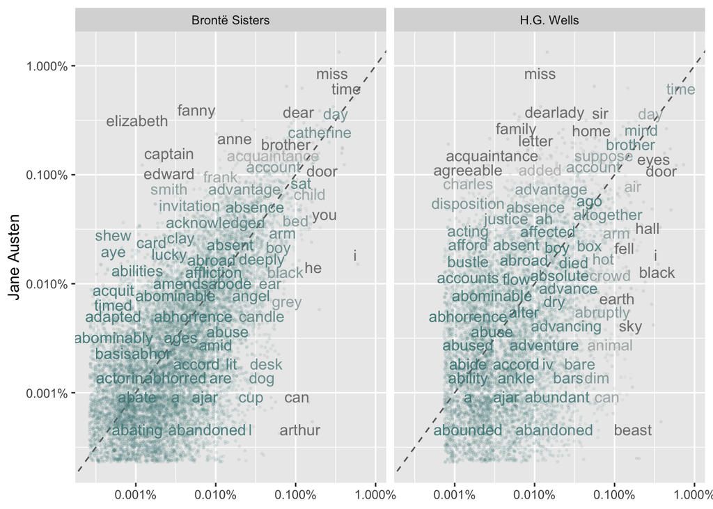

```r
library(scales)

# expect a warning about rows with missing values being removed
ggplot(frequency, aes(x = proportion, y = `Jane Austen`,
                      color = abs(`Jane Austen` - proportion))) +
  geom_abline(color = "gray40", lty = 2) +
  #you can use geom_jitter to adjust the points location and gain visibility
  geom_jitter(alpha = 0.1, size = 0.5, width = 0.3, height = 0.3) +
  geom_text(aes(label = word), check_overlap = TRUE, vjust = 0.5) +
  scale_x_log10(labels = percent_format()) +
  scale_y_log10(labels = percent_format()) +
  scale_color_gradient(limits = c(0, 0.001),
                       low = "darkslategray4", high = "gray75") +
  facet_wrap(~author, ncol = 2) +
  theme(legend.position="none") +
  labs(y = "Jane Austen", x = NULL)
```

Rules to read the plot:

- We’ve got the high frequency area, at the upper right end, and the low frequency area, at the lower left end.
- Words that are close to the line in these plots have similar frequencies in both sets of texts.
- Words that are far from the line are words that are found more in one set of texts than another.

**Exercise**:

Make some guesses about the style of H.G. Wells vs. Jane Austen. Are they so different?

Make some guesses about the style of Jane Austen vs. the Brontës. Are they so close?

### Calculating correlation

We have been making guesses at first sight, strongly influenced by our intuition and our knowledge about the authors. To see if we are right, let’s **quantify** now how similar and different these sets of word frequencies are.

**Correlation is** **a statistical measure that expresses the extent to which two variables are linearly related** (meaning they change together at a constant rate).

- Talking about word frequencies: a higher correlation means word frequencies are more similar.

We will be using the Pearson **correlation coefficient**, which is the most common way of measuring a correlation. It is a number between -1 and 1 that measures the strength and direction of the relationship between two variables.

Let’s see if it is higher for Austen-Brontë or for Austen-H.G.Wells.

```r
cor.test(data = frequency[frequency$author == "Brontë Sisters",],
         ~ proportion + `Jane Austen`)
```

```
##
##  Pearson's product-moment correlation
##
## data:  proportion and Jane Austen
## t = 102.03, df = 9788, p-value < 2.2e-16
## alternative hypothesis: true correlation is not equal to 0
## 95 percent confidence interval:
##  0.7081871 0.7273894
## sample estimates:
##       cor
## 0.7179248
```

And just repeat the code for Austen-H.G. Wells.

## Summary

We have learned so far:

- How to tokenize a text into single words
- How to filter stop words using a preset library
- How to count word frequencies
- How to compare word frequencies in multiple texts
- How to make a plot with word frequencies for multiple texts
- How to quantify correlations between word frequencies in multiple texts